# PP02

## Autores

Carlos Augusto Jardim Chiarelli 165685

Marco Antonio D'Angelo 173656

Bruno Hassan Mouazzem 165240

$$ $$

# ES672 – Sistemas Fluidotérmicos I – turma A

```python
# bibliotecas
import numpy  as np
from pandas   import DataFrame
from platform import python_version
from warnings import filterwarnings

filterwarnings('ignore')

def mostra_valor(nomeVar, valor, unidade, arrendondar=2):
    return DataFrame({'variável': nomeVar,
                    'valor':    np.around(valor, arrendondar),
                    'unidade':  unidade},
                    index=[0])

print('Versão da Linguagem Python usada neste relatório:', python_version())
```

```
Versão da Linguagem Python usada neste relatório: 3.6.9
```

# Enunciado

Considere um espaço de 1100 m² em que as cargas térmicas estimadas em um dia típico de verão correspondem ao que é mostrado nas Figuras 1 e 2. O perfil das temperaturas de bulbo seco do ar externo é mostrado na Figura 3. As cargas térmicas correspondem às parcelas devido à ocupação por pessoas (cargas latente e sensível), energia dissipada por equipamentos eletrônicos e iluminação, trocas de calor pelas paredes e pelo teto, energia solar que incide pelas janelas, etc. O sistema de controle térmico é central, e água gelada a até 2°C, proveniente de um chiller (equipamento de refrigeração que reduz a temperatura da água), é usada para reduzir a temperatura do fluxo de ar que é insuflado no espaço. Um esquema de instalação similar é apresentado na Figura 4.

Suponha um equipamento de refrigeração por compressão de vapor de R134a que deve operar de forma a resfriar a água até 2°C, e que a temperatura ambiente externa no local em que a unidade vai ser instalada pode chegar a 35°C. No condensador do sistema de refrigeração, como a troca de calor é com o ar, a diferença de temperatura entre os fluidos deve ser 10°C; já no evaporador, como a troca de calor é com água, a diferença de temperatura entre os fluidos deve ser 5°C. Suponha que o compressor, que opera com rotação constante, tenha eficiência isentrópica 85%.

As cargas térmicas máximas são observadas às 14 e 15 horas, correspondendo a 37 kW de carga latente e (arredondando) 74 kW de carga sensível. Simplificadamente, as menores cargas térmicas são observadas na madrugada, alcançando em média 7,5 kW (no total).

Na Tabela 1 são apresentados os estados termodinâmicos que correspondem à operação do sistema de controle térmico, na condição de máxima carga térmica. O estados correspondem aos pontos A, E, C (S=C), e Z (ver Figura 5).

```python
# Tabela 1: Estados termodinâmicos e fluxos mássicos (de ar úmido) na condição de operação do sistema de controle térmico
#           para anular as cargas térmicas máximas
T1 = DataFrame({'Ponto'                        : ['A', 'Z', 'E', 'C=S'],
                'Localização'                  : ['Ambiente externo', 'Dentro do espaço', 'Fluxos misturados', 'Ar insuflado no espaço'],
                'Temperatura bulbo seco (ºC)'  : [28, 22, 22.5, 9.5],
                'Umidade relativa (%)'         : [70, 60, 61, 100],
                'Umidade específica (g/kg)'    : [16.69, 9.89, 10.45, 7.4],
                'Fluxo mássico de ar (kg/s)'   : [0.48, '', 5.84, 5.84]})

T1.head()
```

|  | Ponto | Localização | Temperatura bulbo seco (ºC) | Umidade relativa (%) | Umidade específica (g/kg) | Fluxo mássico de ar (kg/s) |
| --- | --- | --- | --- | --- | --- | --- |
| 0 | A | Ambiente externo | 28.0 | 70 | 16.69 | 0.48 |
| 1 | Z | Dentro do espaço | 22.0 | 60 | 9.89 |  |
| 2 | E | Fluxos misturados | 22.5 | 61 | 10.45 | 5.84 |
| 3 | C=S | Ar insuflado no espaço | 9.5 | 100 | 7.40 | 5.84 |

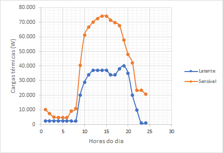

Figura 1: Cargas térmicas sensível e latente no interior da edificação, em W, em um dia típico

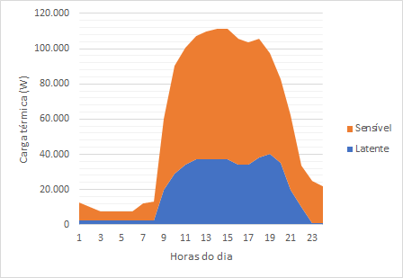

Figura 2: Detalhamento da carga térmica no interior da edificação, em W, em um dia típico

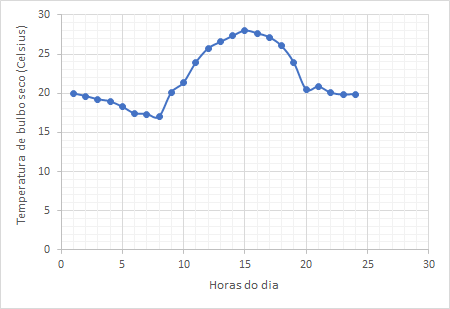

Figura 3: Temperatura de bulbo seco do ar, externo à edificação, em um dia típico

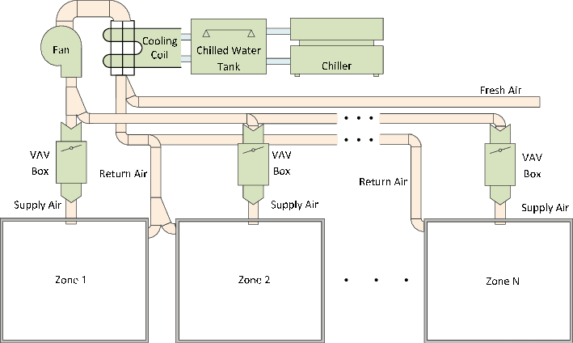

Figura 4: Esquema do sistema de controle térmico central

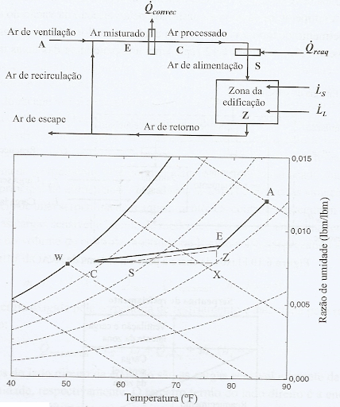

Figura 5: Esquema do sistema de controle térmico central e indicação dos estados termodinâmicos em carta psicrométrica

[figure not shown]

Figura 6: Carta psicrométrica para pressão ambiente 101,325 kPa

# **Questão 01)**

Para a máxima carga térmica, qual o fluxo mássico necessário de água gelada no cooling coil (ver Figura 4)? Suponha que há perdas de 5% (em relação ao efeito útil – i.e. ar resfriado), que a mínima diferença de temperaturas entre os fluxos de ar e de água seja 5°C, e que a elevação de temperatura da água no processo é de 4°C.

## Resolução

Fazendo o balanço de energia no "cooling coil", sendo estado 2 após a troca de energia e considerando o efeito e carga total (latente + sensível):

$$$$$$ \dot Q_{in} = \dot m (h_{2}-h_{1}) = \frac{Carga_{sen}+Carga_{lat}}{1- efeito_{util}} $$

$$$$

Água entra à 2°C e sai à 6°C. Considerando ela incompressível, foram obtidas as propriedades de água líquida satudara do "Moran Shapiro" com interpolação.

Isolando $\dot m$ obtemos o fluxo mássico.

```python
# [kJ/kg]
h1 = np.interp(2, xp=[0.01, 4], fp=[0.01, 16.78])*1e3 # interpolação
h2 = 25.2e3

Carga_sen   = 37e3
Carga_lat   = 74e3
efeito_util = 0.05

Q_cooling = (Carga_sen+Carga_lat)/(1-efeito_util)
m_ponto = Q_cooling/(h2-h1)

mostra_valor('m_ponto', m_ponto, 'kg/s')
```

|  | variável | valor | unidade |
| --- | --- | --- | --- |
| 0 | m_ponto | 6.94 | kg/s |

# **Questão 02)**

Para as condições de carga máxima, calcule o COP do sistema de refrigeração. Qual a potência necessária para acionamento do compressor do chiller? Suponha que há perdas de 2% no evaporador (em relação ao efeito útil – i.e. água resfriada).

## Resolução

$$$$

- $T_{1} = 2 - 5 = -3°C$ (evaporador) $$$$
- $T_{3} = 35 + 10 = 45°C$ (condensador) $$$$

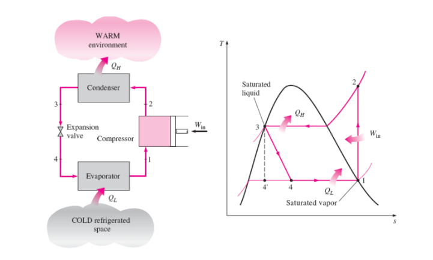

```python
# [kJ/kg]
h1 = np.interp(-3, xp=[-4, 0], fp=[244.9,  247.23])*1e3 # interpolação
s1 = np.interp(-3, xp=[-4, 0], fp=[0.9213, 0.9190])*1e3

h3 = np.interp(45, xp=[44, 48], fp=[112.22, 118.38])*1e3
p3 = np.interp(45, xp=[44, 48], fp=[11.299, 12.526])     # bar

p2 = p3
s2 = s1*1e-3

T_p10 = np.interp(s2, xp=[.9066, .9428], fp=[40, 50])
T_p12 = np.interp(s2, xp=[.9164, .9527], fp=[50, 60])
T2    = np.interp(p2, xp=[10, 12],       fp=[T_p10, T_p12])


h_p10 = np.interp(s2, xp=[.9066, .9428], fp=[268.68, 280.19])
h_p12 = np.interp(s2, xp=[.9164, .9527], fp=[275.52, 287.44])
h2    = np.interp(p2, xp=[10, 12],       fp=[h_p10, h_p12])

# em 4 fluido é mistura liquido-vapor
h4 = h3
```

```python
mostra_valor(['T2'], [T2], ['°C'])
```

|  | variável | valor | unidade |
| --- | --- | --- | --- |
| 0 | T2 | 49.75 | °C |

```python
mostra_valor(['h2'], [h2], ['kJ/kg'])
```

|  | variável | valor | unidade |
| --- | --- | --- | --- |
| 0 | h2 | 276.2 | kJ/kg |

```python
h2 *= 1e3
```

$$$$

A partir das seguintes considerações e expressões, conseguimos obter o COP: $$$$ $$ \dot Q_{evaporador} = \dot Q_{cooling} $$ $$$$ $$ \dot m = \frac{\dot Q_{evaporador}}{h_{1}-h_{4}} (1-perda_{evap}) $$ $$$$ $$ \dot W = \dot m (h_{2s}-h_{1}) $$ $$$$ $$ \beta = \frac{\dot Q_{in}}{\dot W} $$ $$$$

```python
Q_evap     = Q_cooling
perda_evap = 0.02
m_ponto    = Q_evap/(h1-h4)*(1-perda_evap)

W_ponto = m_ponto*(h2-h1)

beta = Q_cooling/W_ponto

mostra_valor('COP', beta, 'adimensional')
```

[output not shown]

|  | variável | valor | unidade |
| --- | --- | --- | --- |
| 0 | COP | 4.38 | adimensional |

# **Questão 03)**

Indique os processos termodinâmicos (PTAC) que estão associados à transição entre os estados (i.e. os processos A-E, E-C, etc.). Indique esses estados em uma carta psicrométrica (ver Figura 6).

$$$$

## Resolução

$$$$

- O processo A-E é uma mistura adiabática de duas correntes de ar úmido. A corrente de arque se junta com A é a Z. $$$$
- O processo E-C é Resfriamento e desumidifição de ar úmido. $$$$
- O processo S-Z é Ganho de calor e ganho de umidade.

[figure not shown]

# **Questão 04)**

Na mesma carta psicométrica, indique os estados termodinâmicos A-E-S-Z supondo a operação do sistema às 19 horas (carga térmica total 97,7 kW, sendo 40 kW a carga latente).

$$$$

## Resolução

[figure not shown]

# **Questão 05)**

Como é feito o controle operacional do sistema? Por exemplo, se o sistema foi dimensionado e está ajustado para “anular” as cargas térmicas às 15 horas, o que é feito para que opere adequadamente, às 8 horas, ou às 19 horas?

$$$$

## Resolução

Como o sistema é ajustado para "anular" as cargas térmicas às 15 horas, quando a temperatura externa está entre as maiores do dia, os horários em que a temperatura externa for mais baixa acarretarão um resfriamento maior do que o desejado. Para contornar esse problema, um sistema de controle deve ser instalado, controlando através de uma válvula o fluxo de ar que é insuflado de modo a manter a temperatura interna mais estável.

$$$$

# **Questão 06)**

Supondo que a tarifa elétrica seja variável durante o dia, qual a alternativa para que o sistema opere adequadamente, mas com menor custo operacional?

$$$$

## Resolução

Utilizando um compressor de rotação variável, é possível desenvolver um sistema de controle que reduza a rotação do compressor quando a demanda térmia for menor, resolvendo não só o problema anterior, já que esse sistema é capaz de manter a temperatura interna mais constante, como também reduzindo o custo operacional do sistema, já que em horários mais frios o compressor necessita de menos potência.

$$$$